# IMPORTANT INFORMATION

The tcR package WILL SOON BE ORPHANED AND REMOVED FROM CRAN.

A new package is available that is designed to replace tcR: immunarch – http://immunarch.com/

We will be happy to help you to move to the new package. Feel free to contact us: http://github.com/immunomind/immunarch

Sincerely, immunarch dev team and Vadim I. Nazarov, lead developer of tcR

## Introduction

The *tcR* package designed to help researchers in the immunology field to analyse T cell receptor (`TCR`) and immunoglobulin (`Ig`) repertoires. In this vignette, I will cover procedures for immune receptor repertoire analysis provided with the package.

Terms:

- Clonotype: a group of T / B cell clones with equal CDR3 nucleotide sequences and equal Variable genes.
- Cloneset / repertoire: a set of clonotypes. Represented as a data frame in which each row corresponds to a unique clonotype.
- UMI: Unique Molecular Identifier (see this [paper](http://www.nature.com/nmeth/journal/v9/n1/full/nmeth.1778.html) for details)

### Package features

- Parsers for outputs of various tools for CDR3 extraction and genes alignment *(currently implemented parsers for MiTCR, MiGEC, VDJtools, ImmunoSEQ, IMSEQ and MiXCR)*
- Data manipulation *(in-frame / out-of-frame sequences subsetting, clonotype motif search)*
- Descriptive statistics *(number of reads, number of clonotypes, gene segment usage)*
- Shared clonotypes statistics *(number of shared clonotypes, using V genes or not; sequential intersection among the most abundant clonotype (“top-cross”))*
- Repertoire comparison *(Jaccard index, Morisita’s overlap index, Horn’s index, Tversky index, overlap coefficient)*
- V- and J genes usage and it’s analysis *(PCA, Shannon Entropy, Jensen-Shannon Divergence)*
- Diversity evaluation *(ecological diversity index, Gini index, inverse Simpson index, rarefaction analysis)*
- Artificial repertoire generation (beta chain only, for now)
- Spectratyping
- Various visualisation procedures
- Mutation networks *(graphs, in which vertices represent CDR3 nucleotide / amino acid sequences and edges are connecting similar sequences with low hamming or edit distance between them)*

### Data in the package

There are two datasets provided with the package - twins data and V(D)J recombination genes data.

#### Downsampled twins data

`twa.rda`, `twb.rda` - two lists with 4 data frames in each list. Every data frame is a sample downsampled to the 10000 most abundant clonotypes of twins data (alpha and beta chains). Full data is available here:

[Twins TCR data at Laboratory of Comparative and Functional Genomics](http://labcfg.ibch.ru/tcr.html)

Explore the data:

```r
# Load the package and load the data.
library(tcR)
data(twa)  # "twa" - list of length 4
data(twb)  # "twb" - list of length 4

# Explore the data.
head(twa[[1]])
head(twb[[1]])
```

#### Gene alphabets

Gene alphabets - character vectors with names of genes for TCR and Ig.

```r
# Run help to see available alphabets.
?genealphabets
?genesegments
data(genesegments)
```

### Quick start / automatic report generation

For the exploratory analysis of a single repertoire, use the RMarkdown report file at

`"<path to the tcR package>/inst/library.report.Rmd"`

Analysis in the file include statistics and visualisation of number of clones, clonotypes, in- and out-of-frame sequences, unique amino acid CDR3 sequences, V- and J-usage, most frequent k-mers, rarefaction analysis.

For the analysis of a group of repertoires (“cross-analysis”), use the RMarkdown report file at:

`"<path to the tcR package>/inst/crossanalysis.report.Rmd}"`

Analysis in this file include statistics and visualisation of number of shared clones and clonotypes, V-usage for individuals and groups, J-usage for individuals, Jensen-Shannon divergence among V-usages of repertoires and top-cross.

You need the *knitr* package installed in order to generate reports from default pipelines. In RStudio you can run a pipeline file as follows:

`Run RStudio -> load the pipeline .Rmd files -> press the knitr button`

### Input parsing

Currently in *tcR* there are implemented parser for the next software:

- MiTCR - `parse.mitcr`;
- MiTCR w/ UMIs - `parse.mitcrbc`;
- MiGEC - `parse.migec`;
- VDJtools - `parse.vdjtools`;
- ImmunoSEQ - `parse.immunoseq`;
- MiXCR - `parse.mixcr`;
- IMSEQ - `parse.imseq`.

Also a general parser `parse.cloneset` for a text table files is implemented. General wrapper for parsers is `parse.file`. User can also parse a list of files or the entire folder. Run `?parse.folder` to see a help on parsing input files and a list of functions for parsing a specific input format.

```r
# Parse file in "~/mitcr/immdata1.txt" as a MiTCR file.
immdata1 <- parse.file("~/mitcr_data/immdata1.txt", 'mitcr')
# equivalent to
immdata1.eq <- parse.mitcr("~/mitcr_data/immdata1.txt")

# Parse folder with MiGEC files.
immdata <- parse.folder("~/migec_data/", 'migec')
```

### Cloneset representation

Clonesets represented in *tcR* as data frames with each row corresponding to the one nucleotide clonotype and with specific column names:

- *Umi.count* - number of UMIs;
- *Umi.proportion* - proportion of UMIs;
- *Read.count* - number of reads;
- *Read.proportion* - proportion of reads;
- *CDR3.nucleotide.sequence* - CDR3 nucleotide sequence;
- *CDR3.amino.acid.sequence* - CDR3 amino acid sequence;
- *V.gene* - names of aligned Variable genes;
- *J.gene* - names of aligned Joining genes;
- *D.gene* - names of aligned Diversity genes;
- *V.end* - last positions of aligned V genes (1-based);
- *J.start* - first positions of aligned J genes (1-based);
- *D5.end* - positions of D’5 end of aligned D genes (1-based);
- *D3.end* - positions of D’3 end of aligned D genes (1-based);
- *VD.insertions* - number of inserted nucleotides (N-nucleotides) at V-D junction (-1 for receptors with VJ recombination);
- *DJ.insertions* - number of inserted nucleotides (N-nucleotides) at D-J junction (-1 for receptors with VJ recombination);
- *Total.insertions* - total number of inserted nucleotides (number of N-nucleotides at V-J junction for receptors with VJ recombination).

Any data frame with this columns and of this class is suitable for processing with the package, hence user can generate their own table files and load them for the further analysis using `read.csv`, `read.table` and other `base` R functions. Please note that *tcR* internally expects all strings to be of class “character”, not “factor”. Therefore you should use R parsing functions with parameter *stringsAsFactors=FALSE*.

```r
# No D genes is available here hence "" at "D.genes" and "-1" at positions.
str(twa[[1]])
```

```
## 'data.frame':    10000 obs. of  16 variables:
##  $ Umi.count               : logi  NA NA NA NA NA NA ...
##  $ Umi.proportion          : logi  NA NA NA NA NA NA ...
##  $ Read.count              : int  147158 58018 55223 41341 31525 30682 20913 16695 14757 13745 ...
##  $ Read.proportion         : num  0.0857 0.0338 0.0322 0.0241 0.0184 ...
##  $ CDR3.nucleotide.sequence: chr  "TGTGCTGTGATGGATAGCAACTATCAGTTAATCTGG" "TGTGCAGAGAAGTCTAGCAACACAGGCAAACTAATCTTT" "TGTGTGGTGAACTTTACTGGAGGCTTCAAAACTATCTTT" "TGTGCAGCAAGTATAGGGCTTGTATCTAACTTTGGAAATGAGAAATTAACCTTT" ...
##  $ CDR3.amino.acid.sequence: chr  "CAVMDSNYQLIW" "CAEKSSNTGKLIF" "CVVNFTGGFKTIF" "CAASIGLVSNFGNEKLTF" ...
##  $ V.gene                  : chr  "TRAV1-2" "TRAV5" "TRAV12-1" "TRAV13-1" ...
##  $ J.gene                  : chr  "TRAJ33" "TRAJ37" "TRAJ9" "TRAJ48" ...
##  $ D.gene                  : chr  "" "" "" "" ...
##  $ V.end                   : int  9 9 11 12 9 8 4 12 9 12 ...
##  $ J.start                 : int  10 12 14 22 19 9 15 13 15 14 ...
##  $ D5.end                  : int  -1 -1 -1 -1 -1 -1 -1 -1 -1 -1 ...
##  $ D3.end                  : num  -1 -1 -1 -1 -1 -1 -1 -1 -1 -1 ...
##  $ VD.insertions           : int  -1 -1 -1 -1 -1 -1 -1 -1 -1 -1 ...
##  $ DJ.insertions           : int  -1 -1 -1 -1 -1 -1 -1 -1 -1 -1 ...
##  $ Total.insertions        : int  0 2 2 9 9 0 10 0 5 1 ...
```

```r
str(twb[[1]])
```

```
## 'data.frame':    10000 obs. of  16 variables:
##  $ Umi.count               : logi  NA NA NA NA NA NA ...
##  $ Umi.proportion          : logi  NA NA NA NA NA NA ...
##  $ Read.count              : int  81516 46158 32476 30356 27321 23760 22232 20968 20603 17429 ...
##  $ Read.proportion         : num  0.0578 0.0327 0.023 0.0215 0.0194 ...
##  $ CDR3.nucleotide.sequence: chr  "TGTGCCAGCAGCCAAGCTCTAGCGGGAGCAGATACGCAGTATTTT" "TGTGCCAGCAGCTTAGGCCCCAGGAACACCGGGGAGCTGTTTTTT" "TGTGCCAGCAGTTATGGAGGGGCGGCAGATACGCAGTATTTT" "TGCAGTGCTGGAGGGATTGAAACCTCCTACAATGAGCAGTTCTTC" ...
##  $ CDR3.amino.acid.sequence: chr  "CASSQALAGADTQYF" "CASSLGPRNTGELFF" "CASSYGGAADTQYF" "CSAGGIETSYNEQFF" ...
##  $ V.gene                  : chr  "TRBV4-2" "TRBV13" "TRBV12-4, TRBV12-3" "TRBV20-1" ...
##  $ J.gene                  : chr  "TRBJ2-3" "TRBJ2-2" "TRBJ2-3" "TRBJ2-1" ...
##  $ D.gene                  : chr  "TRBD2" "TRBD1, TRBD2" "TRBD2" "TRBD1, TRBD2" ...
##  $ V.end                   : int  15 16 12 12 13 9 11 14 12 14 ...
##  $ J.start                 : int  18 17 15 13 20 15 14 16 15 17 ...
##  $ D5.end                  : int  27 20 20 15 23 21 19 18 17 21 ...
##  $ D3.end                  : int  28 23 25 23 24 22 21 23 20 28 ...
##  $ VD.insertions           : int  2 0 2 0 6 5 2 1 2 2 ...
##  $ DJ.insertions           : int  0 2 4 7 0 0 1 4 2 6 ...
##  $ Total.insertions        : int  2 2 6 7 6 5 3 5 4 8 ...
```

## Repertoire descriptive statistics

For the exploratory analysis *tcR* provides various functions for computing descriptive statistics.

### Cloneset summary

To get a general view of a subject’s repertoire (overall count of sequences, in- and out-of-frames numbers and proportions) use the `cloneset.stats` function. It returns a `summary` of counts of nucleotide and amino acid clonotypes, as well as summary of read counts:

```r
cloneset.stats(twb)
```

```
##        #Nucleotide clones #Aminoacid clonotypes %Aminoacid clonotypes
## Subj.A              10000                  9850                0.9850
## Subj.B              10000                  9838                0.9838
## Subj.C              10000                  9775                0.9775
## Subj.D              10000                  9872                0.9872
##        #In-frames %In-frames #Out-of-frames %Out-of-frames Sum.reads Min.reads
## Subj.A       9622     0.9622            346         0.0346   1410263        22
## Subj.B       9564     0.9564            400         0.0400   2251408        20
## Subj.C       9791     0.9791            192         0.0192    969949        23
## Subj.D       9225     0.9225            712         0.0712   1419130        32
##        1st Qu.reads Median.reads Mean.reads 3rd Qu.reads Max.reads
## Subj.A           26           33   141.0263           57     81516
## Subj.B           24           31   225.1408           55    171230
## Subj.C           28           39    96.9949           68    104628
## Subj.D           37           48   141.9130           83     33588
```

For characterisation of a library use the `repseq.stats` function:

```r
repseq.stats(twb)
```

```
##        Clones Sum.reads Reads.per.clone
## Subj.A  10000   1410263          141.03
## Subj.B  10000   2251408          225.14
## Subj.C  10000    969949           96.99
## Subj.D  10000   1419130          141.91
```

### Most abundant clonotypes statistics

Function `clonal.proportion` is used to get the number of most abundant by the count of reads clonotypes. E.g., compute number of clonotypes which fill up (approx.) the 25% from total repertoire’s “Read.count”:

```r
                            # How many clonotypes fill up approximately
clonal.proportion(twb, 25)  # the 25% of the sum of values in 'Read.count'?
```

```
##        Clones Percentage Clonal.count.prop
## Subj.A     12       25.1            0.0012
## Subj.B      6       26.5            0.0006
## Subj.C      7       25.2            0.0007
## Subj.D     38       25.2            0.0038
```

To get a proportion of the most abundant clonotypes’ sum of reads to the overall number of reads in a repertoire, use `top.proportion`, i.e. get

($\sum$ reads of top clonotypes)$/$($\sum$ reads for all clonotypes).

E.g., get a proportion of the top-10 clonotypes’ reads to the overall number of reads:

```r
                          # What accounts a proportion of the top-10 clonotypes' reads
top.proportion(twb, 10)   # to the overall number of reads?
```

```
##    Subj.A    Subj.B    Subj.C    Subj.D
## 0.2289069 0.3648699 0.2620158 0.1305398
```

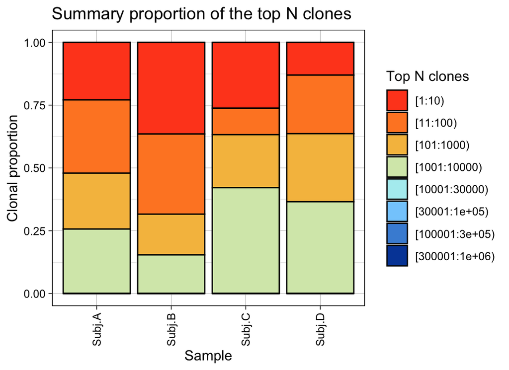

```r
vis.top.proportions(twb)  # Plot this proportions.
```

```r
                                # What is a proportion of sequences which
                                # have 'Read.count' <= 100 to the
tailbound.proportion(twb, 100)  # overall number of reads?
```

```
## Subj.A Subj.B Subj.C Subj.D
## 0.8651 0.8641 0.8555 0.8020
```

### Clonal space homeostasis

Clonal space homeostasis is a useful statistics of how many space occupied by clonotypes with specific proportions.

```r
# data(twb)
# Compute summary space of clones, that occupy
# [0, .05) and [.05, 1] proportion.
clonal.space.homeostasis(twb, c(Low = .05, High = 1))
```

```
##        Low (0 < X <= 0.05) High (0.05 < X <= 1)
## Subj.A           0.9421980           0.05780198
## Subj.B           0.9239454           0.07605463
## Subj.C           0.8279270           0.17207296
## Subj.D           1.0000000           0.00000000
```

```r
# Use default arguments:
clonal.space.homeostasis(twb[[1]])
```

```
##        Rare (0 < X <= 1e-05) Small (1e-05 < X <= 1e-04)
## Sample                     0                  0.2589567
##        Medium (1e-04 < X <= 0.001) Large (0.001 < X <= 0.01)
## Sample                   0.2130291                 0.2666893
##        Hyperexpanded (0.01 < X <= 1)
## Sample                      0.261325
```

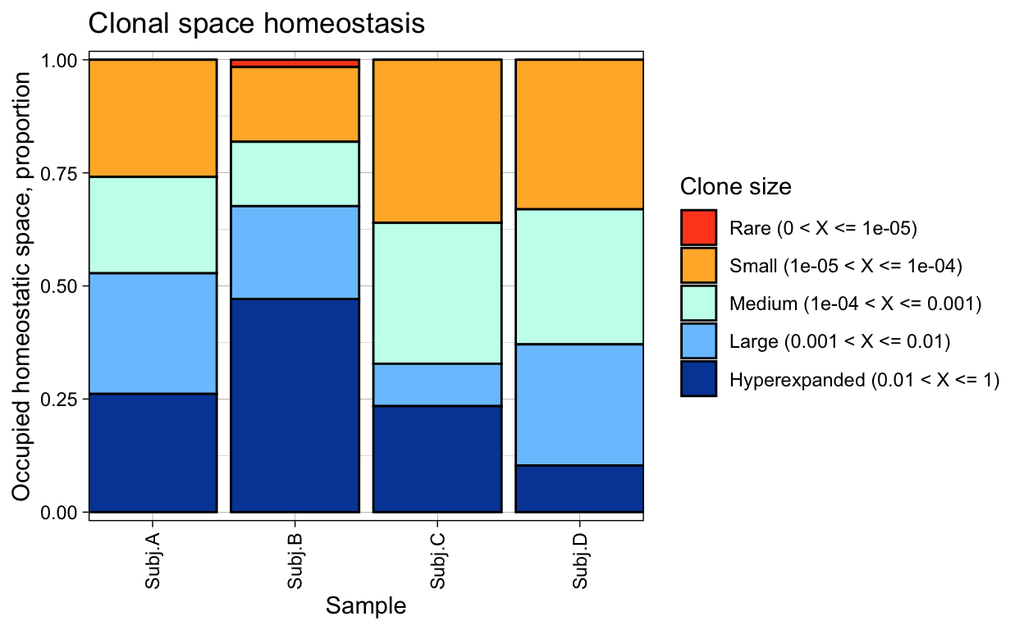

```r
twb.space <- clonal.space.homeostasis(twb)
vis.clonal.space(twb.space)
```

### In-frame and out-of-frame sequences

Functions for performing subsetting and counting number of in-frame and out-of-frame clonotypes are: `count.inframes`, `count.outframes`, `get.inframes`, `get.outframes`. Parameter *.head* for this functions is a parameter to the *.head* function, that applied to the input data frame or an input list of data frames before subsetting. Functions accept both data frames and list of data frames as parameters. E.g., get data frame with only in-frame sequences and count out-of-frame sequences in the first 5000 rows for this data frame:

```r
imm.in <- get.inframes(twb) # Return all in-frame sequences from the 'twb'.

                            # Count the number of out-of-frame sequences
count.outframes(twb, 5000)  # from the first 5000 sequences.
```

```
## Subj.A Subj.B Subj.C Subj.D
##    172    212     73    326
```

General functions with parameter stands for ‘all’ (all sequences), ‘in’ (only in-frame sequences) or ‘out’ (only out-of-frame sequences) are *get.frames* and *count.frames*:

```r
imm.in <- get.frames(twb, 'in') # Similar to 'get.inframes(twb)'.

count.frames(twb[[1]], 'all')   # Just return number of rows.
```

```
## [1] 10000
```

```r
flag <- 'out'
count.frames(twb, flag, 5000)   # Similar to 'count.outframes(twb, 5000)'.
```

```
## Subj.A Subj.B Subj.C Subj.D
##    172    212     73    326
```

### Search for a target CDR3 sequences

For exact or fuzzy search of sequences the package employed a function `find.clonotypes`. Input arguments for this function are a data frame or a list of data frames, targets (a character vector or data frame having one column with sequences and additional columns with, e.g., V genes), a value of which column or columns to return, a method to be used to compare sequences among each other (either “exact” for exact matching, “hamm” for matching sequences by Hamming distance (two sequences are matched if H $\leq$ 1) or “lev” for matching sequences by Levenshtein distance (two sequences are matched if L $\leq$ 1)), and column name from which sequences for matching are obtained. Sounds very complex, but in practice it’s very easy, therefore let’s go to examples.

Suppose we want to search for some CDR3 sequences in a number of repertoires:

```r
cmv <- data.frame(CDR3.amino.acid.sequence = c('CASSSANYGYTF', 'CSVGRAQNEQFF', 'CASSLTGNTEAFF', 'CASSALGGAGTGELFF', 'CASSLIGVSSYNEQFF'),
                  V.genes = c('TRBV4-1', 'TRBV4-1', 'TRBV4-1', 'TRBV4-1', 'TRBV4-1'), stringsAsFactors = F)

cmv
```

```
##   CDR3.amino.acid.sequence V.genes
## 1             CASSSANYGYTF TRBV4-1
## 2             CSVGRAQNEQFF TRBV4-1
## 3            CASSLTGNTEAFF TRBV4-1
## 4         CASSALGGAGTGELFF TRBV4-1
## 5         CASSLIGVSSYNEQFF TRBV4-1
```

We will search for them using all methods of matching (exact, hamming or levenshtein) and with and without matching by V-segment. Also, for the first case (exact matching and without V gene) we return “Total.insertions” column along with the “Read.count” column, and for the second case output will be a “Rank” - rank (generated by `set.rank`) of a clone or a clonotype in a data frame.

```r
twb <- set.rank(twb)
# Case 1.
cmv.imm.ex <-
  find.clonotypes(.data = twb[1:2], .targets = cmv[,1], .method = 'exact',
                  .col.name = c('Read.count', 'Total.insertions'),
                  .verbose = F)
head(cmv.imm.ex)
```

```
##                    CDR3.amino.acid.sequence Read.count.Subj.A Read.count.Subj.B
## CASSALGGAGTGELFF           CASSALGGAGTGELFF               153               319
## CASSALGGAGTGELFF.1         CASSALGGAGTGELFF                NA                35
## CASSLTGNTEAFF                 CASSLTGNTEAFF                35               263
## CASSLTGNTEAFF.1               CASSLTGNTEAFF                35                35
## CASSLTGNTEAFF.2               CASSLTGNTEAFF                NA                28
## CASSSANYGYTF                   CASSSANYGYTF                NA             15320
##                    Total.insertions.Subj.A Total.insertions.Subj.B
## CASSALGGAGTGELFF                         9                      10
## CASSALGGAGTGELFF.1                      NA                       9
## CASSLTGNTEAFF                            2                       2
## CASSLTGNTEAFF.1                          1                       0
## CASSLTGNTEAFF.2                         NA                       1
## CASSSANYGYTF                            NA                       1
```

```r
# Case 2.
# Search for CDR3 sequences with hamming distance <= 1
# to the one of the cmv$CDR3.amino.acid.sequence with
# matching V genes. Return ranks of found sequences.
cmv.imm.hamm.v <-
  find.clonotypes(twb[1:3], cmv, 'hamm', 'Rank',
                  .target.col = c('CDR3.amino.acid.sequence',
                                  'V.gene'),
                  .verbose = F)
head(cmv.imm.hamm.v)
```

```
##                  CDR3.amino.acid.sequence  V.gene Rank.Subj.A Rank.Subj.B
## CASSALGGAGTGELFF         CASSALGGAGTGELFF TRBV4-1          NA          NA
## CASSLIGVSSYNEQFF         CASSLIGVSSYNEQFF TRBV4-1          NA          NA
## CASSLTGNTEAFF               CASSLTGNTEAFF TRBV4-1          NA          NA
## CASSSANYGYTF                 CASSSANYGYTF TRBV4-1          NA          NA
## CSVGRAQNEQFF                 CSVGRAQNEQFF TRBV4-1          NA          NA
##                  Rank.Subj.C
## CASSALGGAGTGELFF          NA
## CASSLIGVSSYNEQFF          NA
## CASSLTGNTEAFF             NA
## CASSSANYGYTF              NA
## CSVGRAQNEQFF              NA
```

```r
# Case 3.
# Similar to the previous example, except
# using levenshtein distance and the "Read.count" column.
cmv.imm.lev.v <-
  find.clonotypes(twb[1:3], cmv, 'lev',
                  .target.col = c('CDR3.amino.acid.sequence', 'V.gene'),
                  .verbose = F)
head(cmv.imm.lev.v)
```

```
##                  CDR3.amino.acid.sequence  V.gene Read.count.Subj.A
## CASSALGGAGTGELFF         CASSALGGAGTGELFF TRBV4-1                NA
## CASSLIGVSSYNEQFF         CASSLIGVSSYNEQFF TRBV4-1                NA
## CASSLTGNTEAFF               CASSLTGNTEAFF TRBV4-1                NA
## CASSSANYGYTF                 CASSSANYGYTF TRBV4-1                NA
## CSVGRAQNEQFF                 CSVGRAQNEQFF TRBV4-1                NA
##                  Read.count.Subj.B Read.count.Subj.C
## CASSALGGAGTGELFF                NA                NA
## CASSLIGVSSYNEQFF                NA                NA
## CASSLTGNTEAFF                   NA                NA
## CASSSANYGYTF                    NA                NA
## CSVGRAQNEQFF                    NA                NA
```

## Gene usage

Variable and Joining gene usage (V-usage and J-usage) are important characteristics of repertoires. To access and compare them among repertoires *tcR* provides a few useful functions.

### Gene usage computing

```r
imm1.vs <- geneUsage(twb[[1]], HUMAN_TRBV)
```

[output not shown]

```r
head(imm1.vs)
```

```
##       Gene Sample
## 2 TRBV10-1     40
## 3 TRBV10-2     48
## 4 TRBV10-3    308
## 5 TRBV11-1     43
## 6 TRBV11-2    186
## 7 TRBV11-3     20
```

```r
imm.vs.all <- geneUsage(twb, HUMAN_TRBV)
```

[output not shown]

```r
imm.vs.all[1:10, 1:4]
```

```
##        Gene Subj.A Subj.B Subj.C
## 2  TRBV10-1     40     35      9
## 3  TRBV10-2     48     65     22
## 4  TRBV10-3    308    307    328
## 5  TRBV11-1     43     34     33
## 6  TRBV11-2    186    230    223
## 7  TRBV11-3     20     23     27
## 8  TRBV12-3      0      0      0
## 9  TRBV12-4      0      0      0
## 10 TRBV12-5     15     22     37
## 11   TRBV13     68     39     44
```

You can also directly visualise gene usage with the function `vis.gene.usage` (if you pass the gene alphabet as a second argument):

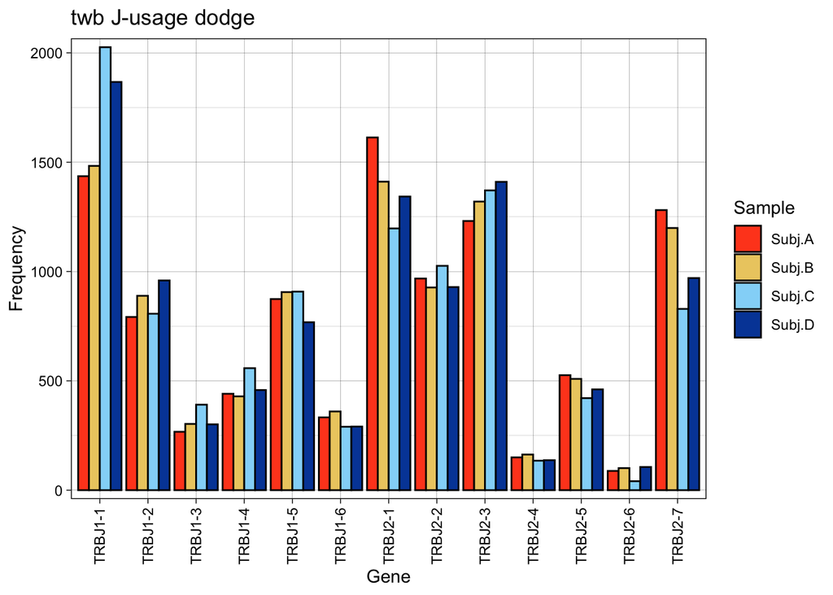

```r
# Put ".dodge = F" to get distinct plot for every data frame in the given list.
vis.gene.usage(twb, HUMAN_TRBJ, .main = 'twb J-usage dodge', .dodge = T)
```

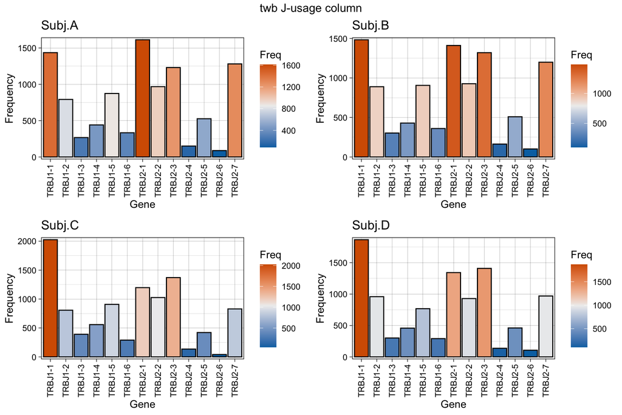

```r
vis.gene.usage(twb, HUMAN_TRBJ, .main = 'twb J-usage column', .dodge = F, .ncol = 2)
```

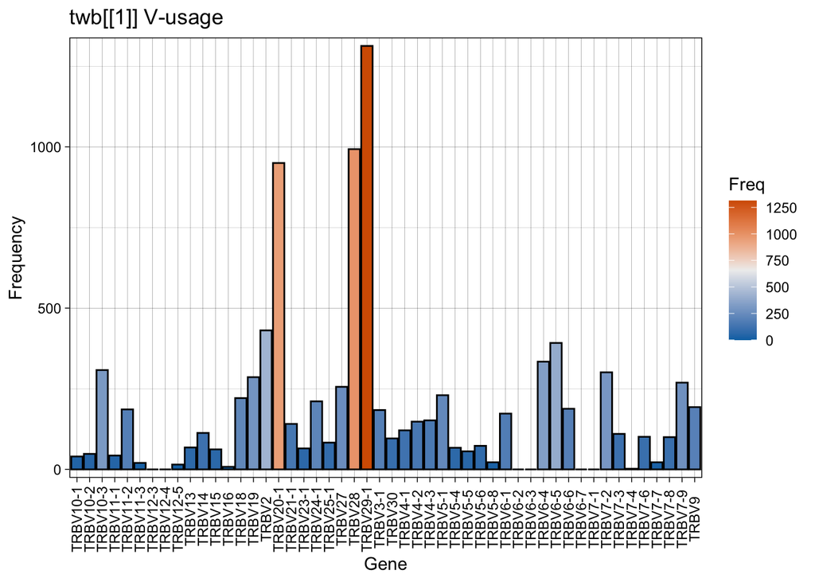

```r
vis.gene.usage(imm1.vs, NA, .main = 'twb[[1]] V-usage', .coord.flip = F)
```

### Gene usage comparing

To evaluate V- and J genes usage of repertoires, the package implements subroutines for two approaches to the analysis: measures from the information theory and PCA (Principal Component Analysis).

#### Shannon entropy and Jensen-Shannon divergence

To assess the diversity of genes usage user can use the `entropy` function. Kullback-Leibler assymetric measure (function `kl.div`) and Jensen-Shannon symmetric measure (functions `js.div` for computing JS-divergence between the given distributions and `js.div.seg` for computing JS-divergence between genes distributions of two clonesets or a list with data frames) are provided to estimate distance among gene usage of different repertoires. To visualise distances *tcR* employed the `vis.radarlike` function, see Section “Plots” for more detailed information.

```r
                              # Transform "0:100" to distribution with Laplace correction
entropy(0:100, .laplace = 1)  # (i.e., add "1" to every value before transformation).
```

```
## [1] 6.399261
```

```r
entropy.seg(twb, HUMAN_TRBV)  # Compute entropy of V-segment usage for each data frame.
```

[output not shown]

[output cut: 21 more lines]

[output not shown]

```
##   Subj.A   Subj.B   Subj.C   Subj.D
## 4.684783 4.751303 4.591658 4.539259
```

```r
js.div.seg(twb[1:2], HUMAN_TRBV, .verbose = F)
```

[output not shown]

```
## [1] 0.0008587249
```

```r
imm.js <- js.div.seg(twb, HUMAN_TRBV, .verbose = F)
```

[output not shown]

[output cut: 173 more lines]

[output not shown]

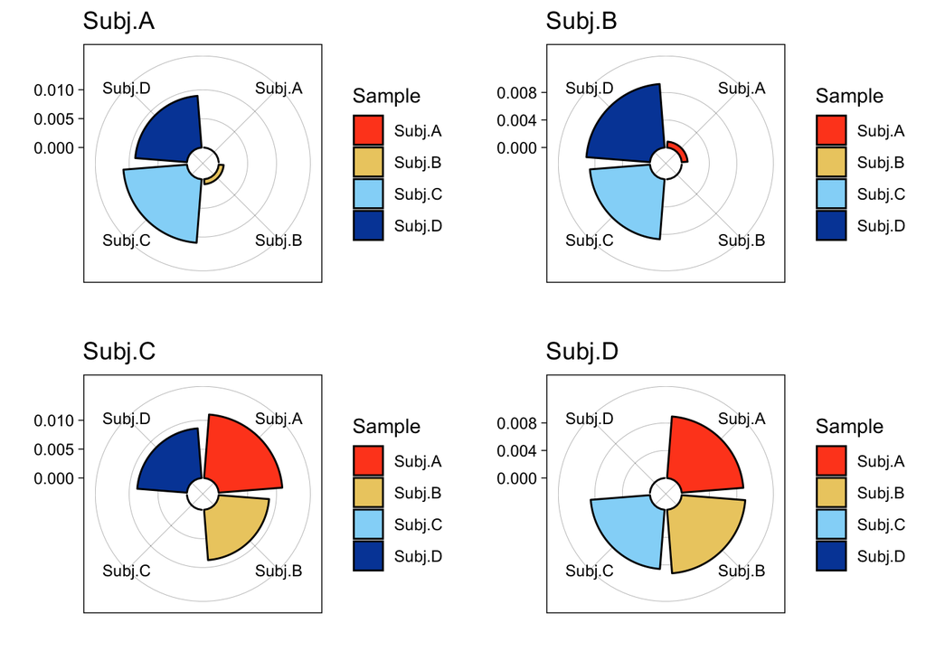

```r
vis.radarlike(imm.js, .ncol = 2)
```

#### Principal Component Analysis (PCA)

Principal component analysis (PCA) is a statistical procedure for transforming a set of observations to a set of special values for analysis. In *tcR* implemented functions `pca.segments` for performing PCA on V- or J-usage, and `pca.segments.2D` for performing PCA on VJ-usage. For plotting the PCA results see the `vis.pca` function.

[output not shown]

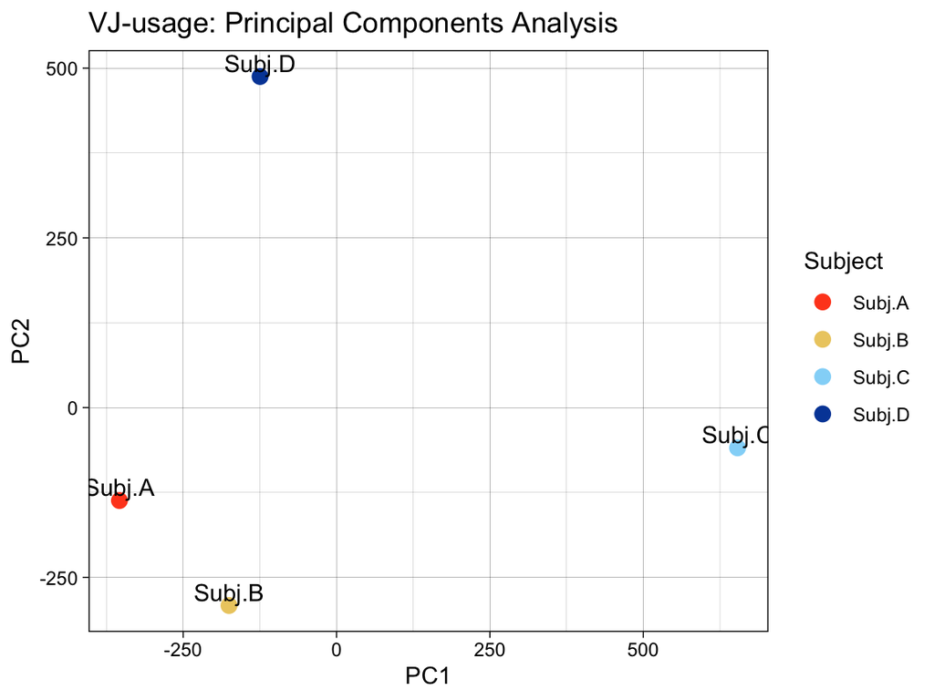

```r
pca.segments(twb, .genes = HUMAN_TRBV)  # Plot PCA results of V-segment usage.
```

```r
# Return object of class "prcomp"
class(pca.segments(twb, .do.plot = F, .genes = HUMAN_TRBV))
```

[output not shown]

```
## [1] "prcomp"
```

## Repertoire overlap analysis

*tcR* provides a number of functions for evaluating similarity of clonesets based on shared among clonesets clonotypes and working with data frames with shared clonotypes.

### Overlap quantification

The general interface to all functions for computing cloneset overlap coefficients is the `repOverlap` function.

#### Number of shared clonotypes

The most straightforward yet a quite effective way to evaluate similarity of two clonesets is compute the number of shared clonotypes. *tcR* adds the new function `intersectClonesets` (`repOverlap(your_data, 'exact')`) which is by default computes the number of shared clonotypes using the “CDR3.nucleotide.sequence” columns of the given data frames, but user can change target columns by using arguments *.type* or *.col*. As in the `find.clonotypes`, user can choose which method apply to the elements: exact match of elements, match by Hamming distance or match by Levenshtein distance. Logical argument *.norm* is used to perform normalisation of the number of shared clonotypes by dividing this number by multiplication of clonesets’ sizes (**strongly** recommended otherwise your results will be correlating with clonesets’ sizes).

```r
# Equivalent to intersect(twb[[1]]$CDR3.nucleotide.sequence,
#                         twb[[2]]$CDR3.nucleotide.sequence)
repOverlap(twb[1:2], 'exact', 'nuc', .verbose = F)
```

[output not shown]

```
## [1] 4.6e-07
```

```r
# Equivalent to intersectClonesets(twb, "n0e", .norm = T)
repOverlap(twb, 'exact', 'nuc', .norm = T, .verbose = F)
```

[output not shown]

```
##         Subj.A  Subj.B  Subj.C  Subj.D
## Subj.A      NA 4.6e-07 4.4e-07 4.0e-07
## Subj.B 4.6e-07      NA 2.7e-07 2.7e-07
## Subj.C 4.4e-07 2.7e-07      NA 6.2e-07
## Subj.D 4.0e-07 2.7e-07 6.2e-07      NA
```

```r
# Intersect by amino acid clonotypes + V genes
repOverlap(twb, 'exact', 'aa', .vgene = T, .verbose = F)
```

[output not shown]

```
##          Subj.A   Subj.B   Subj.C   Subj.D
## Subj.A       NA 1.58e-06 6.50e-07 5.80e-07
## Subj.B 1.58e-06       NA 5.60e-07 4.70e-07
## Subj.C 6.50e-07 5.60e-07       NA 1.31e-06
## Subj.D 5.80e-07 4.70e-07 1.31e-06       NA
```

[output not shown]

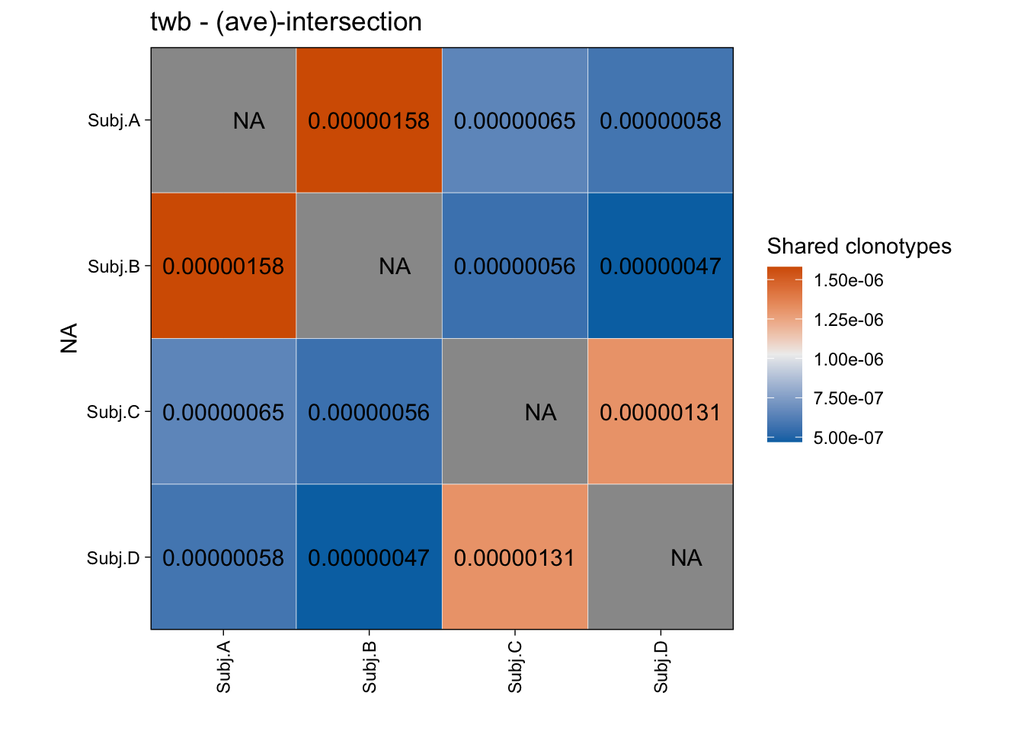

```r
# Plot a heatmap of the number of shared clonotypes.
vis.heatmap(repOverlap(twb, 'exact', 'aa', .vgene = T, .verbose = F), .title = 'twb - (ave)-intersection', .labs = '')
```

See the `vis.heatmap` function in the Section “Visualisation” for the visualisation of the intersection results.

Functions `intersectCount`, `intersectLogic` and `intersectIndices` are more flexible in terms of choosing which columns to match. They all have parameter *.col* that specifies names of columns which will used in computing intersection. Function `intersectCount` returns number of similar elements; `intersectIndices(x, y)` returns 2-column matrix with the first column stands for an index of an element in the given *x*, and the second column stands for an index of that element of *y* which is similar to a relative element in *x*; `intersectLogic(x, y)` returns a logical vector of *length(x)* or *nrow(x)*, where TRUE at position *i* means that element with index {i} has been found in the *y*.

```r
# Get logic vector of shared elements, where
# elements are tuples of CDR3 nucleotide sequence and corresponding V-segment
imm.1.2 <- intersectLogic(twb[[1]], twb[[2]],
                           .col = c('CDR3.amino.acid.sequence', 'V.gene'))
# Get elements which are in both twb[[1]] and twb[[2]].
head(twb[[1]][imm.1.2, c('CDR3.amino.acid.sequence', 'V.gene')])
```

```
##    CDR3.amino.acid.sequence V.gene
## 8             CASSLGLHYEQYF TRBV28
## 14            CAWSRQTNTEAFF TRBV30
## 17            CASSLGVGYEQYF TRBV28
## 19            CASSLGLHYEQYF TRBV28
## 30            CASSLGLNYEQYF TRBV28
## 66            CASSLGVSYEQYF TRBV28
```

#### “Top cross”

Number of shared clonotypes among the most abundant clonotypes may differ signigicantly from those with lesses count. To support research *tcR* offers the `top.cross` function, that apply `tcR::intersectClonesets`, e.g., to the first 1000 clonotypes, 2000, 3000 and so on up to the first 100000 clones, if supplied `.n == seq(1000, 100000, 1000)`.

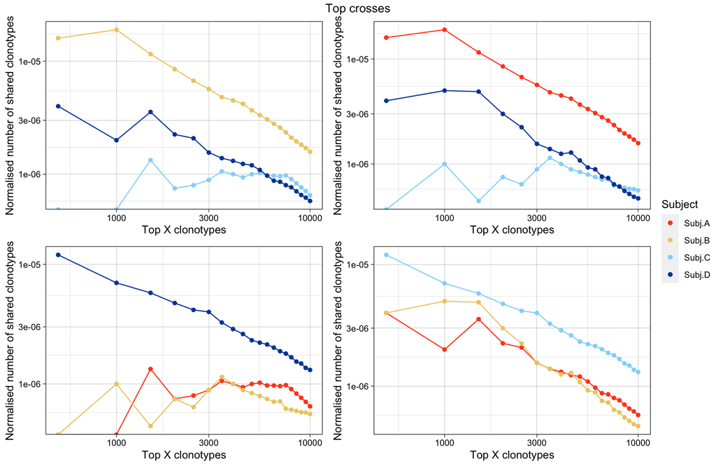

```r
twb.top <- top.cross(.data = twb, .n = seq(500, 10000, 500), .verbose = F, .norm = T)
top.cross.plot(twb.top)
```

#### More complex similarity measures

*tcR* also provides more complex similarity measures for evaluating the similarity of sets.

- Tversky index (`repOverlap(your_data, 'tversky')` for clonesets or `tversky.index` for vectors) is an asymmetric similarity measure on sets that compares a variant to a prototype. If using default arguments, it’s similar to Dice’s coefficient.
- Overlap coefficient (`repOverlap(your_data, 'overlap')` for clonesets or `overlap.coef` for vectors) is a similarity measure that measures the overlap between two sets, and is defined as the size of the intersection divided by the smaller of the size of the two sets.
- Jaccard index (`repOverlap(your_data, 'jaccard')` for clonesets or `jaccard.index` for vectors) is a statistic used for comparing the similarity and diversity of sample sets.
- Morisita’s overlap index (`repOverlap(your_data, 'morisita')` for clonesets or `morisitas.index` for other data) is a statistical measure of dispersion of individuals in a population and is used to compare overlap among samples. The formula is based on the assumption that increasing the size of the samples will increase the diversity because it will include different habitats (i.e. different faunas) (Morisita, 1959).

To visualise similarity among repertoires the `vis.heatmap` function is appropriate.

```r
# Apply the Morisitas overlap index to the each pair of repertoires.
# Use information about V genes (i.e. one CDR3 clonotype is equal to another
# if and only if their CDR3 aa sequences are equal and their V genes are equal)
repOverlap(twb, 'morisita', 'aa', 'read.count', .vgene = T, .verbose = F)
```

[output not shown]

```
##              Subj.A       Subj.B       Subj.C       Subj.D
## Subj.A           NA 2.353362e-03 2.125406e-05 0.0002231617
## Subj.B 2.353362e-03           NA 9.765356e-06 0.0002413103
## Subj.C 2.125406e-05 9.765356e-06           NA 0.0004875433
## Subj.D 2.231617e-04 2.413103e-04 4.875433e-04           NA
```

### Overlap statistics and tests

`ozScore`

#### Monte Carlo permutation test for pairwise and one-vs-all-wise within- and inter-group differences in a set of repertoires

`permutDistTest`

`pca2euclid`

### Shared repertoire

To investigate a shared among a several repertoires clonotypes (“shared repertoire”) the package provided the `shared.repertoire` function along with functions for computing the shared repertoire statistics. The `shared.representation` function computes the number of shared clonotypes for each repertoire for each degree of sharing (i.e., number of people, in which indicated amount of clones have been found). The function `shared.summary` is equivalent to `repOverlap(, 'exact')` but applies to the shared repertoire data frame. Measuring distances among repertoires using the cosine similarity on vector of counts of shared sequences is also possible with the `cosine.sharing` function.

```r
# Compute shared repertoire of amino acid CDR3 sequences and V genes
# which has been found in two or more people and return the Read.count column
# of such clonotypes from each data frame in the input list.
imm.shared <- shared.repertoire(.data = twb, .type = 'avrc', .min.ppl = 2, .verbose = F)
head(imm.shared)
```

```
##   CDR3.amino.acid.sequence  V.gene People Subj.A Subj.B Subj.C Subj.D
## 1            CASSDRDTGELFF TRBV6-4      4    113    411    176   2398
## 2          CASSDSSGGYNEQFF TRBV6-4      4     68    357     31    115
## 3           CASSFLSGTDTQYF  TRBV28      4     36    111     59    203
## 4            CASSGQGNTEAFF   TRBV2      4    223    252     69    152
## 5           CASSLGQGGQPQHF TRBV7-9      4     34    139     31     84
## 6            CASKGQLNTEAFF  TRBV19      3    125     NA     37     34
```

```r
shared.representation(imm.shared)  # Number of shared sequences.
```

```
##   Subj.A Subj.B Subj.C Subj.D
## 1      0      0      0      0
## 2    219    205    192    170
## 3     22     19     20     23
## 4      5      5      5      5
```

## Diversity evaluation

For assessing the distribution of clonotypes in the given repertoire, *tcR* provides functions for evaluating the diversity (functions `diversity` and `inverse.simpson`) and the skewness of the clonal distribution (functions `gini` and `gini.simpson`), and a general interface to all of this functions `repDiversity`, which user should use to estimate the diversity of clonesets. Function `diversity` (`repDiversity(your_clonesets, "div")`) computes the ecological diversity index (with parameter `.q` for penalties for clones with large count). Function `inverse.simpson` (`repDiversity(your_clonesets, "inv.simp")`) computes the Inverse Simpson Index (i.e., inverse probability of choosing two similar clonotypes). Function `gini` (`repDiversity(your_clonesets, "gini")`) computes the economical Gini index of clonal distribution. Function `gini.simpson` (`repDiversity(your_clonesets, "gini.simp")`) computes the Gini-Simpson index. Function `chao1` (`repDiversity(your_clonesets, "chao1")`) computes the Chao1 index, its SD and two 95 perc CI. Function `repDiversity` accepts single clonesets as well as a list of clonesets. Parameter `.quant` specifies which column to use for computing the diversity (print `?repDiversity` to see more information about input arguments).

```r
# Evaluate the diversity of clones by the ecological diversity index.
repDiversity(twb, 'div', 'read.count')
```

[output not shown]

```r
sapply(twb, function (x) diversity(x$Read.count))
```

```
##   Subj.A   Subj.B   Subj.C   Subj.D
## 34.55417 23.97224 15.87257 98.03479
##   Subj.A   Subj.B   Subj.C   Subj.D
## 34.55417 23.97224 15.87257 98.03479
```

```r
# Compute the diversity as the inverse probability of choosing two similar clonotypes.
repDiversity(twb, 'inv.simp', 'read.prop')
```

[output not shown]

```r
sapply(twb, function (x) inverse.simpson(x$Read.proportion))
```

```
##    Subj.A    Subj.B    Subj.C    Subj.D
## 117.63383  56.09537  55.31047 354.18601
##    Subj.A    Subj.B    Subj.C    Subj.D
## 117.63383  56.09537  55.31047 354.18601
```

```r
# Evaluate the skewness of clonal distribution.
repDiversity(twb, 'gini.simp', 'read.prop')
```

[output not shown]

```r
sapply(twb, function (x) gini.simpson(x$Read.proportion))
```

```
##    Subj.A    Subj.B    Subj.C    Subj.D
## 0.9914990 0.9821732 0.9819202 0.9971766
##    Subj.A    Subj.B    Subj.C    Subj.D
## 0.9914990 0.9821732 0.9819202 0.9971766
```

```r
# Compute diversity of repertoire using Chao index.
repDiversity(twb, 'chao1', 'read.count')
```

[output not shown]

```r
sapply(twb, function (x) chao1(x$Read.count))
```

```
##                  Subj.A       Subj.B      Subj.C       Subj.D
## Estimator  1.000000e+04 1.000000e+04 1.00000e+04 1.000000e+04
## SD         5.223297e-04 1.322604e-03 2.90204e-04 2.992252e-06
## Conf.95.lo 1.000000e+04 1.000000e+04 1.00000e+04 1.000000e+04
## Conf.95.hi 1.000000e+04 1.000000e+04 1.00000e+04 1.000000e+04
##                  Subj.A       Subj.B      Subj.C       Subj.D
## Estimator  1.000000e+04 1.000000e+04 1.00000e+04 1.000000e+04
## SD         5.223297e-04 1.322604e-03 2.90204e-04 2.992252e-06
## Conf.95.lo 1.000000e+04 1.000000e+04 1.00000e+04 1.000000e+04
## Conf.95.hi 1.000000e+04 1.000000e+04 1.00000e+04 1.000000e+04
```

## Visualisation

### CDR3 length and read count distributions plot

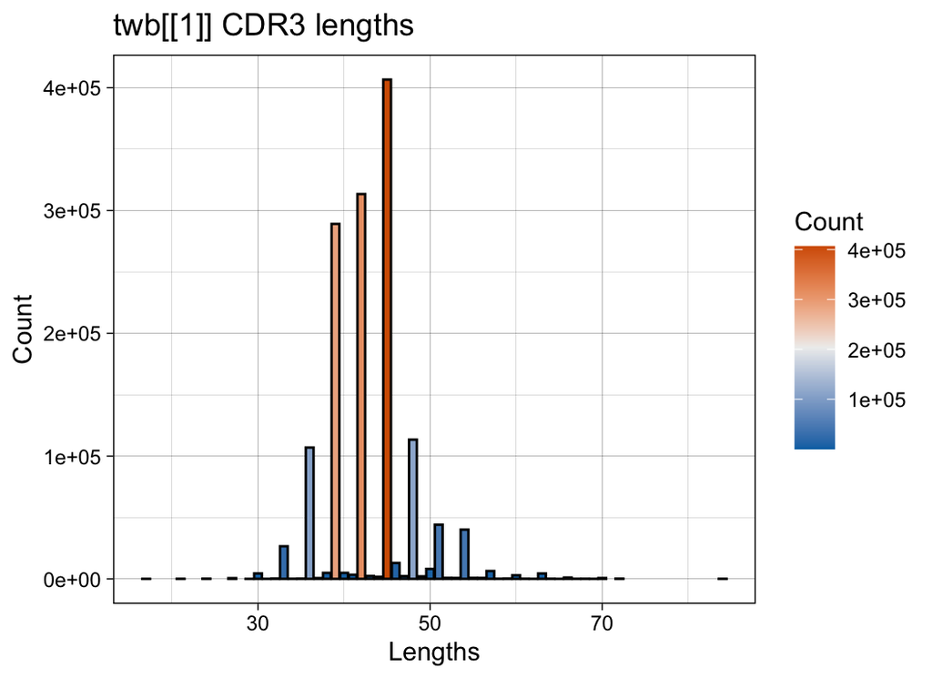

```r
vis.count.len(twb[[1]], .name = "twb[[1]] CDR3 lengths",
              .col = "Read.count")
```

```r
# I comment this to avoid a strange bug in ggplot2. Will uncomment later.
# vis.number.count(twb[[1]], .name = "twb[[1]] count distribution")
```

### Top proportions bar plot

For the visualisation of proportions of the most abundant clonotypes in a repertoire *tcR* offers the `vis.top.proportions` function. As input the function receives either data frame or a list with data frames (argument *.data*), an integer vector with number of clonotypes for computing proportions of count for this clonotypes (argument *.head*), and a column’s name with clonotype counts (argument *.col*).

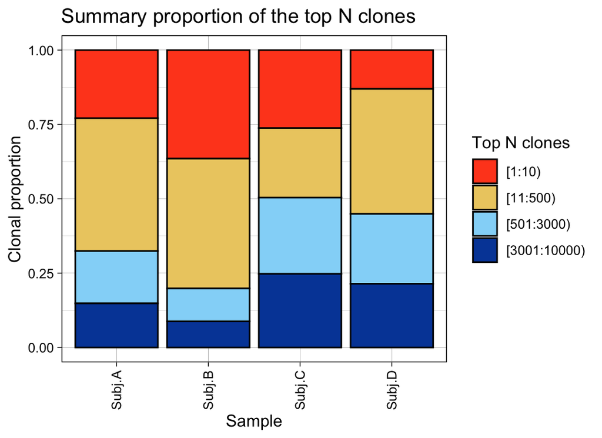

```r
vis.top.proportions(twb, c(10, 500, 3000, 10000), .col = "Read.count")
```

### Clonal space homeostasis bar plot

For the visualisation of how much space occupied each group of clonotypes, divided into groups by their proportions in the data, use the `vis.clonal.space` function. As an input it receives the output of the `clonal.space.homeostasis` function.

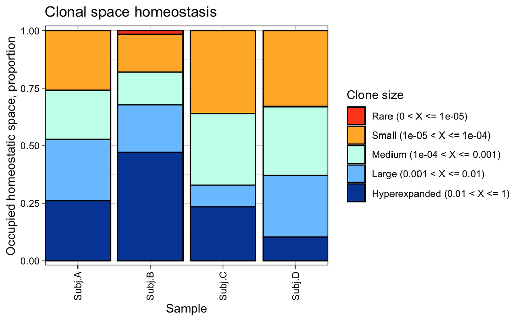

```r
twb.space <- clonal.space.homeostasis(twb)
vis.clonal.space(twb.space)
```

### Heat map

Pairwise distances or similarity of repertoires can be represented as qudratic matrices, in which each row and column represented a cloneset, and each value in every cell (i, j) is a distance between repertoires with indices i and j. One way to visalise such matrices is using “heatmaps”. For plotting heatmaps in *tcR* implemented the `vis.heatmap` function. With changing input arguments user can change names of labs, title and legend.

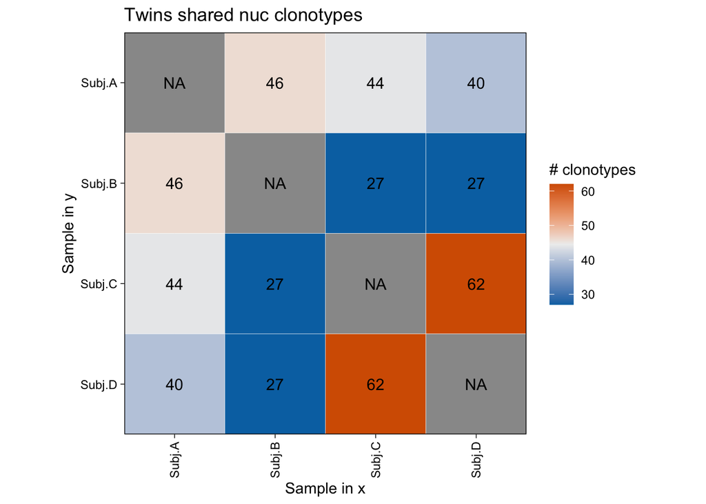

```r
twb.shared <- repOverlap(twb, "exact", .norm = F, .verbose = F)
vis.heatmap(twb.shared, .title = "Twins shared nuc clonotypes",
            .labs = c("Sample in x", "Sample in y"), .legend = "# clonotypes")
```

### Radar-like plot

Another way to repsent distances among objects is “radar-like” plots (because this plots is not exactly radar plots) realised in *tcR* throught the `vis.radarlike` function. Argument *.ncol* specifies a number of columns of radar-like plots in a viewport.

```r
twb.js <- js.div.seg(twb, HUMAN_TRBV, .verbose = F)
```

[output not shown]

[output cut: 173 more lines]

[output not shown]

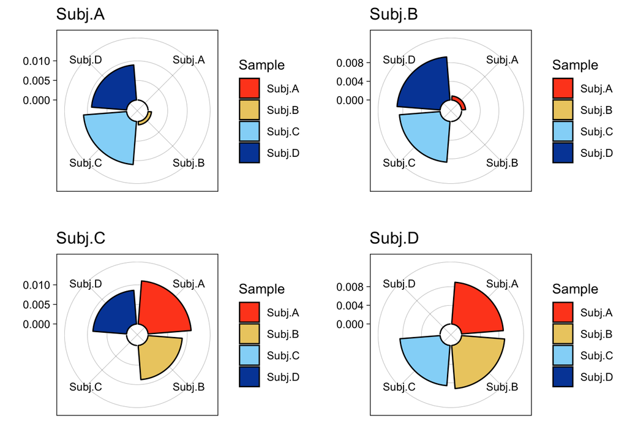

```r
vis.radarlike(twb.js, .ncol = 2)
```

### Gene usage histogram

For the visualisation of gene usage *tcR* employes subroutines for making classical histograms using the `vis.gene.usage` function. The function accept clonesets, lists of clonesets or output from the `geneUsage` function. If input is a cloneset(s), then user should specify a gene alphabet (e.g., `HUMAN_TRBV`) in order to compute the gene usage. Using a parameter , user can change type of the output between an output as histograms for each cloneset in the input list (`.dodge = F`) or an output as an one histogram for all data, which is very useful for comparing distribution of genes (`.dodge = T`). If `.dodge=F` and input are lists of clonesets or a gene usage of a few clonesets, than user with argument `.ncol` can specify how many columns of histograms will be outputted. With `.coord.flip` user can flip coordinates so genes will be at the left side of the plot.

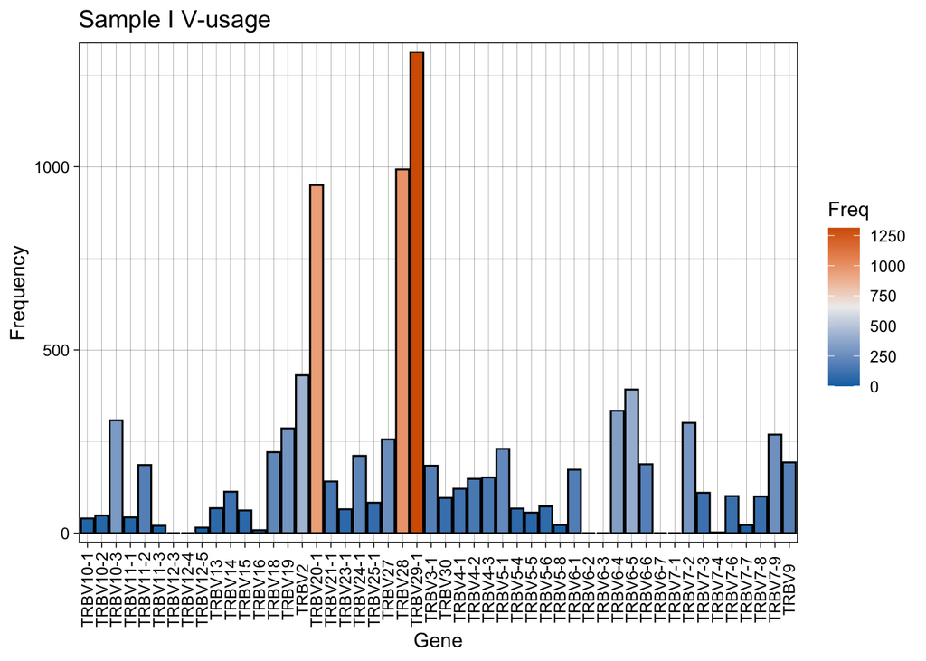

```r
vis.gene.usage(twb[[1]], HUMAN_TRBV, .main = 'Sample I V-usage')
```

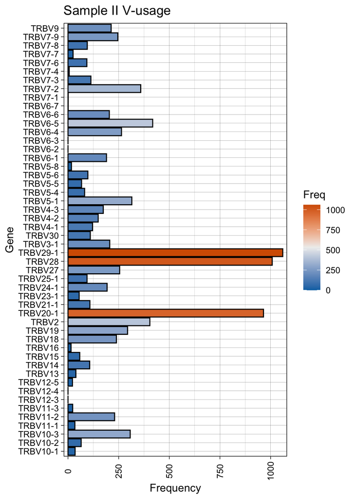

```r
vis.gene.usage(twb[[2]], HUMAN_TRBV, .main = 'Sample II V-usage', .coord.flip = T)
```

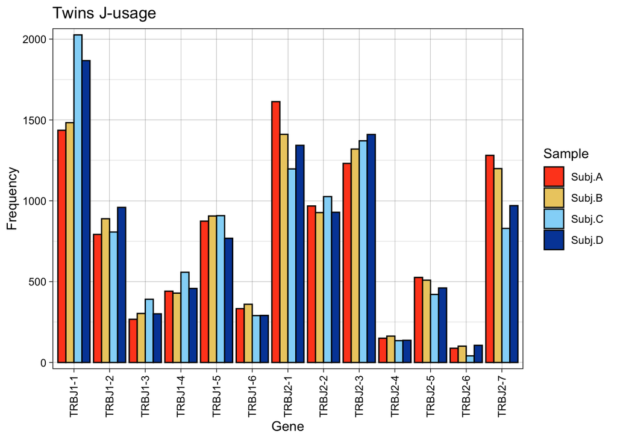

```r
twb.jusage <- geneUsage(twb, HUMAN_TRBJ)
vis.gene.usage(twb.jusage, .main = 'Twins J-usage', .dodge = T)
```

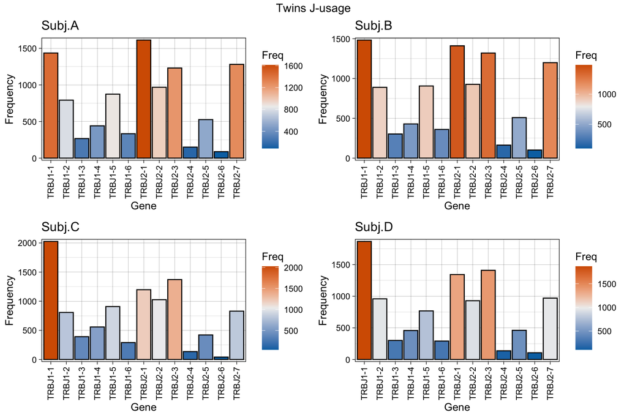

```r
vis.gene.usage(twb, HUMAN_TRBJ, .main = 'Twins J-usage', .dodge = F, .ncol = 2)
```

### PCA visualisation

For the visualisation of results from the `prcomp` function (i.e., objects of class `prcomp`), *tcR* provides the `vis.pca` function. Input arguments for the function are an object of class `prcomp` and a (if needed) list with groups (vectors of indices of samples) for colouring points in the plot.

```r
twb.pca <- pca.segments(twb, .do.plot = F)
```

[output not shown]

[output not shown]

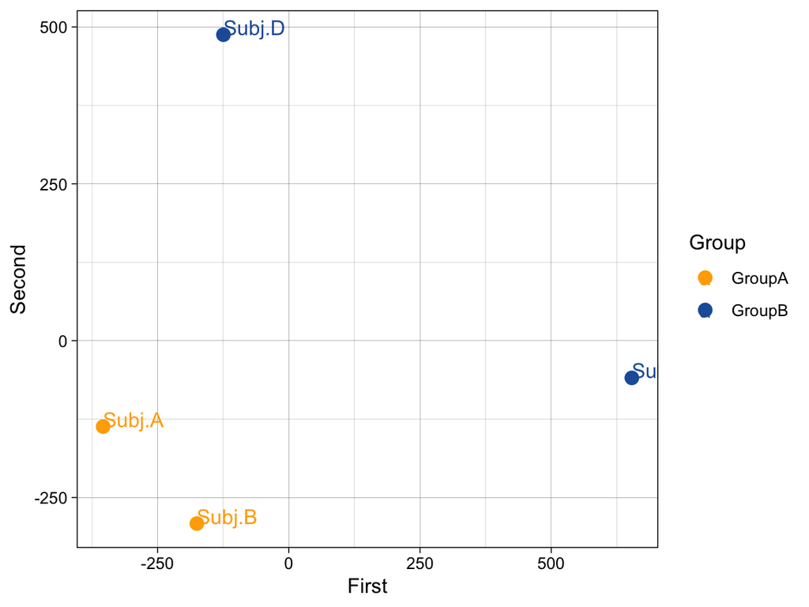

```r
vis.pca(pca.segments(twb, .do.plot = F, .genes = HUMAN_TRBV), .groups = list(GroupA = c(1,2), GroupB = c(3,4)))
```

### Logo-like plot

Logo-like graphs for visualisation of nucleotide or amino acid motif sequences / profiles.

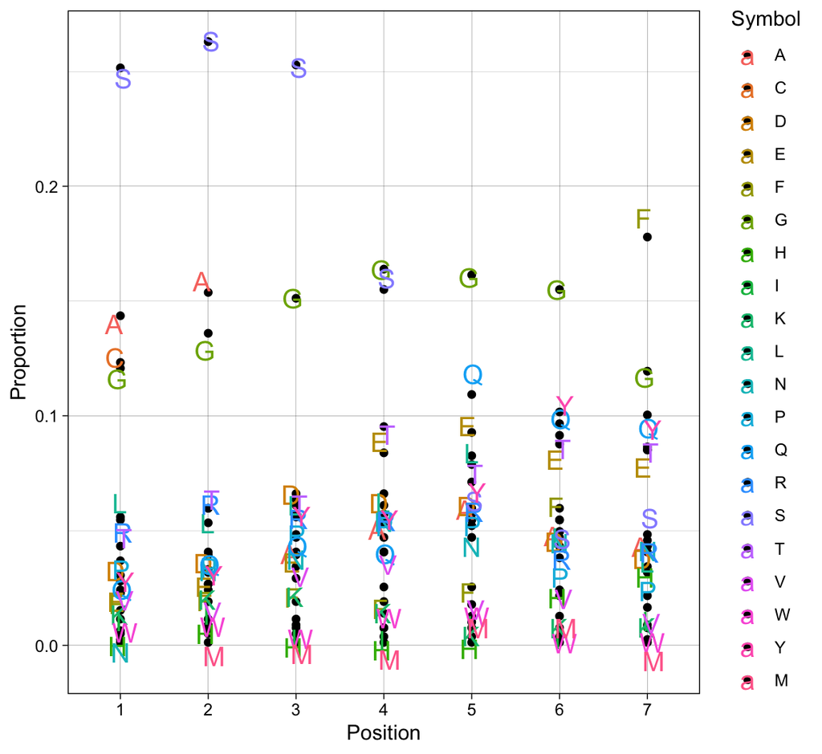

```r
km <- get.kmers(twb[[1]]$CDR3.amino.acid.sequence, .head = 100, .k = 7, .verbose = F)
d <- kmer.profile(km)
vis.logo(d)
```

## Mutation networks

Mutation network (or a mutation graph) is a graph with vertices representing nucleotide or in-frame amino acid sequences (out-of-frame amino acid sequences will be automatically filtered out by *tcR* functions for mutation network creating) and edges which connecting pairs of sequences with hamming distance (parameter *.method* = ‘hamm’) or edit distance (parameter *.method* = ‘lev’) between them no more than specified in the *.max.errors* function parameter of the `mutation.network` function. To create a mutation network first what you need is to make a shared repertoires and then apply the `mutation.network` function to this shared repertoire:

```r
# data(twb)
twb.shared <- shared.repertoire(twb, .head = 1000, .verbose = F)
G <- mutation.network(twb.shared)
G
```

```
## IGRAPH 4cb561c U--- 3704 337 --
## + attr: label (v/c), vseg (v/c), repind (v/n), prob (v/n), people
## | (v/c), npeople (v/n)
## + edges from 4cb561c:
##  [1]   1--  25   1-- 572   1-- 577   1--2671   2-- 765   6-- 613   7-- 617
##  [8]   8-- 616  12-- 787  12-- 789  12-- 798  12--1010  14--1056  14--2432
## [15]  16--1110  18--  19  18--  21  18--1053  18--1264  18--1273  18--1313
## [22]  19--1273  19--1305  19--1327  20--  21  20--1056  20--1327  21--1264
## [29]  21--1313  21--1327  21--2439  23--2106  24--2207  24--2354  29--3175
## [36]  32--2997  73-- 105 127-- 417 219-- 961 235-- 236 239-- 411 289--2646
## [43] 291-- 292 297-- 299 418--2231 423-- 440 439-- 440 460-- 461 463-- 954
## + ... omitted several edges
```

```r
# data(twb)
# twb.shared <- shared.repertoire(twb, .head = 1000)
# G <- mutation.network(twb.shared)
G <- set.group.vector(G, "twins", list(A = c(1,2), B = c(3,4)))  # <= refactor this
get.group.names(G, "twins", 1)
```

```
## [1] "A|B"
```

```r
get.group.names(G, "twins", 300)
```

```
## [1] "B"
```

```r
get.group.names(G, "twins", c(1,2,3), F)
```

```
## [[1]]
## [1] "A" "B"
##
## [[2]]
## [1] "A" "B"
##
## [[3]]
## [1] "B"
```

```r
get.group.names(G, "twins", 300, F)
```

```
## [[1]]
## [1] "B"
```

```r
# Because we have only two groups, we can assign more readable attribute.
V(G)$twin.names <- get.group.names(G, "twins")
V(G)$twin.names[1]
```

```
## [1] "A|B"
```

```r
V(G)$twin.names[300]
```

```
## [1] "B"
```

To access neighbour vertices of vertices (“ego-network”) use the function:

```r
# data(twb)
# twb.shared <- shared.repertoire(twb, .head = 1000)
# G <- mutation.network(twb.shared)
head(mutated.neighbours(G, 1)[[1]])
```

```
##           label             vseg repind prob people npeople twins twin.names
## 1 CASSDRDTGELFF          TRBV6-4      1   -1   0111       3    11        A|B
## 2 CASSYRDTGELFF TRBV6-3, TRBV6-2     25   -1   1001       2    11        A|B
## 3 CASSDRETGELFF          TRBV6-4    572   -1   0100       1    10          A
## 4 CASSDRGTGELFF          TRBV6-4    577   -1   0100       1    10          A
## 5 CASTDRDTGELFF         TRBV10-2   2671   -1   1000       1    10          A
```

## Conclusion

Feel free to contact me for the package-related or immunoinformatics research-related questions.

## Appendix A: Kmers manipulation and processing

In the package implemented functions for working with k-mers. Function `get.kmers` generates k-mers from the given chatacter vector or a data frame with columns for sequences and a count for each sequence.

```r
head(get.kmers(twb[[1]]$CDR3.amino.acid.sequence, 100, .meat = F, .verbose = F))
```

```
##   Kmers Count
## 1 CASSL    20
## 2 CASSP    12
## 3 ASSLG    11
## 4 CASSY    11
## 5 NEQFF    11
## 6 YEQYF    11
```

```r
head(get.kmers(twb[[1]], .meat = T, .verbose = F))
```

```
##   Kmers  Count
## 1 CASSL 283192
## 2 DTQYF 217783
## 3 NEQFF 179230
## 4 CASSQ 158877
## 5 ASSLG 154560
## 6 YEQYF 148602
```

## Appendix B: Nucleotide and amino acid sequences manipulation

The package also provides a several number of functions for performing classic bioinformatics tasks on strings. For more powerful subroutines see the Bioconductor’s *Biostrings* package.

### Nucleotide sequence manipulation

Functions for basic nucleotide sequences manipulations: reverse-complement, translation and GC-content computation. All functions are vectorised.

```r
revcomp(c('AAATTT', 'ACGTTTGGA'))
```

```
## [1] "AAATTT"    "TCCAAACGT"
```

```r
cbind(bunch.translate(twb[[1]]$CDR3.nucleotide.sequence[1:10]),
      twb[[1]]$CDR3.amino.acid.sequence[1:10])
```

```
##       [,1]              [,2]
##  [1,] "CASSQALAGADTQYF" "CASSQALAGADTQYF"
##  [2,] "CASSLGPRNTGELFF" "CASSLGPRNTGELFF"
##  [3,] "CASSYGGAADTQYF"  "CASSYGGAADTQYF"
##  [4,] "CSAGGIETSYNEQFF" "CSAGGIETSYNEQFF"
##  [5,] "CASSPILGEQFF"    "CASSPILGEQFF"
##  [6,] "CASKKDRDYGYTF"   "CASKKDRDYGYTF"
##  [7,] "CASSQQGSGNTIYF"  "CASSQQGSGNTIYF"
##  [8,] "CASSLGLHYEQYF"   "CASSLGLHYEQYF"
##  [9,] "CASSRASSYNSPLHF" "CASSRASSYNSPLHF"
## [10,] "CASSYLGPDDTEAFF" "CASSYLGPDDTEAFF"
```

```r
gc.content(twb[[1]]$CDR3.nucleotide.sequence[1:10])
```

```
##  [1] 0.5333333 0.5777778 0.5238095 0.4888889 0.5555556 0.4871795 0.4523810
##  [8] 0.4871795 0.5555556 0.5333333
```

### Reverse translation subroutines

Function `codon.variants` returns a list of vectors of nucleotide codons for each letter for each input amino acid sequence. Function `translated.nucl.sequences` returns the number of nucleotide sequences, which, when translated, will result in the given amino acid sequence(s). Function `reverse.translation` return all nucleotide sequences, which is translated to the given amino acid sequences. Optional argument `.nucseq` for each of this function provides restriction for nucleotides, which cannot be changed. All functions are vectorised.

```r
codon.variants('LQ')
```

```
## [[1]]
## [[1]][[1]]
## [1] "CTA" "CTC" "CTG" "CTT" "TTA" "TTG"
##
## [[1]][[2]]
## [1] "CAA" "CAG"
```

```r
translated.nucl.sequences(c('LQ', 'CASSLQ'))
```

```
## [1]   12 3456
```

```r
reverse.translation('LQ')
```

```
##  [1] "CTACAA" "CTCCAA" "CTGCAA" "CTTCAA" "TTACAA" "TTGCAA" "CTACAG" "CTCCAG"
##  [9] "CTGCAG" "CTTCAG" "TTACAG" "TTGCAG"
```

```r
translated.nucl.sequences('LQ', 'XXXXXG')
```

```
## [1] 6
```

```r
codon.variants('LQ', 'XXXXXG')
```

```
## [[1]]
## [[1]][[1]]
## [1] "CTA" "CTC" "CTG" "CTT" "TTA" "TTG"
##
## [[1]][[2]]
## [1] "CAG"
```

```r
reverse.translation('LQ', 'XXXXXG')
```

```
## [1] "CTACAG" "CTCCAG" "CTGCAG" "CTTCAG" "TTACAG" "TTGCAG"
```